# Ugalde_hclust

Axela Keeza T. Ugalde

2026-06-11

# Activity 8 - Clustering (Hierarchal)

## Data Preparation

```r
# Data Preparation
library(cluster)
library(tidyverse)
# Data
my_data <- read.csv("morphology_data.csv")
as.data.frame(my_data)
```

```
##          Pop Sex    SVL   TD    OD    HW    HD    HL   HdL   FbL   FtL   HbL
## 1      Luzon   f  80.19 2.16  6.74 11.90 10.41 21.79 17.42 43.38 32.04 73.12
## 2      Luzon   f  83.20 2.24  7.07 11.93 10.29 21.67 15.61 43.71 29.35 69.89
## 3      Luzon   f  83.26 2.51  7.18 11.04 10.55 21.61 16.32 41.24 29.47 66.18
## 4      Luzon   f  83.36 2.23  6.99 11.92 11.63 22.65 16.91 45.32 32.17 73.17
## 5      Luzon   f  83.72 2.55  6.61 11.97 10.27 21.26 17.09 44.19 31.56 73.12
## 6      Luzon   f  84.26 2.39  7.37 11.26 10.71 22.05 19.85 46.09 31.66 71.88
## 7      Luzon   f  85.73 2.51  7.46 12.01 10.45 21.74 17.86 46.68 32.85 74.52
## 8      Luzon   f  85.84 2.75  6.90 12.09 10.67 22.60 17.30 44.95 33.22 72.83
## 9      Luzon   f  86.18 2.41  6.69 11.70 10.34 22.29 17.17 45.57 32.76 76.02
## 10     Luzon   f  87.85 2.21  7.17 11.72 10.10 22.91 18.31 44.51 32.35 73.91
## 11     Luzon   m  89.17 2.24  7.86 11.56 10.77 22.52 17.40 47.74 33.42 78.37
## 12     Luzon   f  89.60 2.86  7.87 12.71 11.09 23.52 18.23 50.31 33.85 81.02
## 13     Luzon   f  89.87 2.65  7.43 11.31 10.64 22.77 17.75 47.03 33.19 75.83
## 14     Luzon   f  89.97 3.01  7.03 12.27 10.85 22.60 19.16 48.73 33.09 77.73
```

[output cut: 391 more lines]

```r
# Remove Non-Numeric Columns
numeric_data <- my_data |>
  select(where(is.numeric))

# Ensure No NA
clean_data <- numeric_data[complete.cases(numeric_data), ]
sum(is.na(clean_data))
```

```
## [1] 0
```

```r
# Standardize
scaled_data <- scale(clean_data)
scaled_data
```

```
##              SVL           TD           OD           HW          HD
## 1   -1.091585063 -1.866041741 -1.352718231 -0.797607414 -0.87151376
## 2   -0.848785206 -1.690751184 -0.978217868 -0.783512288 -0.94085270
## 3   -0.843945342 -1.099145554 -0.853384414 -1.201667720 -0.79061834
## 4   -0.835878901 -1.712662504 -1.069005835 -0.788210663 -0.16656791
## 5   -0.806839716 -1.011500275 -1.500248677 -0.764718785 -0.95240919
## 6   -0.763280937 -1.362081390 -0.637762994 -1.098303456 -0.69816642
## 7   -0.644704263 -1.099145554 -0.535626531 -0.745925282 -0.84840078
## 8   -0.635831178 -0.573273883 -1.171142298 -0.708338277 -0.72127940
## 9   -0.608405281 -1.318258750 -1.409460710 -0.891574927 -0.91196147
## 10  -0.473695725 -1.756485143 -0.864732910 -0.882178176 -1.05063935
## 11  -0.367218711 -1.690751184 -0.081686698 -0.957352186 -0.66349695
## 12  -0.332533017 -0.332249367 -0.070338202 -0.417038987 -0.47859312
## 13  -0.310753628 -0.792387079 -0.569672019 -1.074811578 -0.73861413
## 14  -0.302687188 -0.003579572 -1.023611852 -0.623767515 -0.61727100
```

[output cut: 811 more lines]

```r
# Compute distance matrix using Euclidean distance
euc_data <- dist(scaled_data, method = "euclidean")
```

## Hierarchal (Agglomerative): Ward’s Method

Minimizes within-cluster variance

```r
hc_wards <- hclust(euc_data, method = "ward.D2")
hc_wards
```

```
##
## Call:
## hclust(d = euc_data, method = "ward.D2")
##
## Cluster method   : ward.D2
## Distance         : euclidean
## Number of objects: 202
```

## Hierarchal (Agglomerative): Single Linkage

Computes the Distance between Closest Points

```r
hc_sLink <- hclust(euc_data, method = "single")
hc_sLink
```

```
##
## Call:
## hclust(d = euc_data, method = "single")
##
## Cluster method   : single
## Distance         : euclidean
## Number of objects: 202
```

## Silhouette Loop for Optimal K values

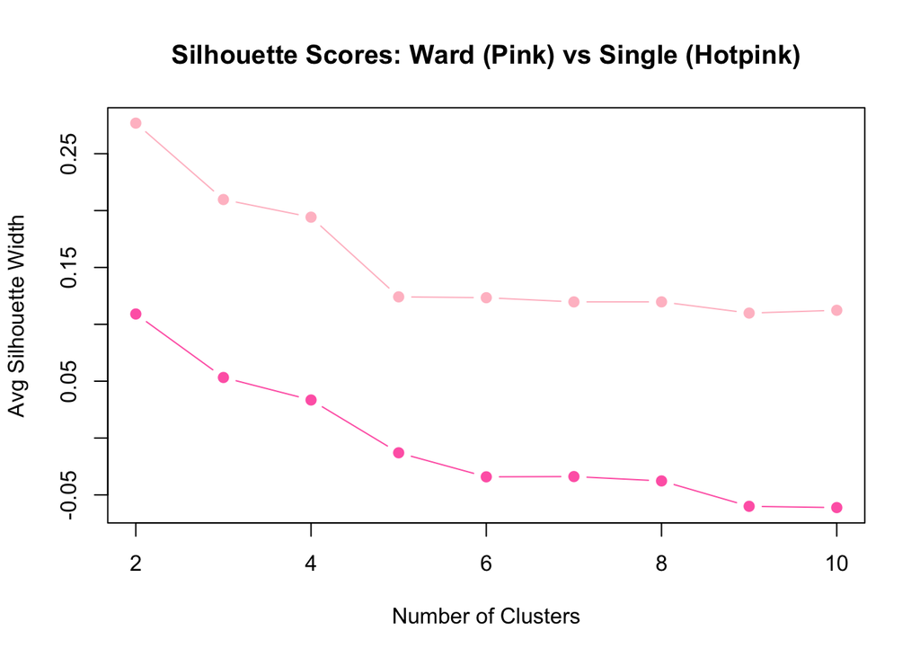

```r
# Setup
k_values <- 2:10
sil_wards <- numeric(length(k_values))
sil_sLink <- numeric(length(k_values))

# Loop for Ward's
for (i in seq_along(k_values)) {
  clusters <- cutree(hc_wards, k = k_values[i])
  sil <- silhouette(clusters, euc_data)
  sil_wards[i] <- mean(sil[, 3]) # Extract average silhouette width
}

# Loop for Single Linkage
for (i in seq_along(k_values)) {
  clusters <- cutree(hc_sLink, k = k_values[i])
  sil <- silhouette(clusters, euc_data)
  sil_sLink[i] <- mean(sil[, 3])
}

# Plot Results
y_limits <- range(c(sil_wards, sil_sLink))

plot(k_values, sil_wards,
     type = "b",
     pch = 19,
     col = "pink",
     ylim = y_limits, # <--- This ensures NO lines get cut off
     xlab = "Number of Clusters",
     ylab = "Avg Silhouette Width",
     main = "Silhouette Scores: Ward (Pink) vs Single (Hotpink)")

lines(k_values, sil_sLink,
      type = "b",
      pch = 19,
      col = "hotpink")
```

Ward’s Method Optimal K: 2 with a score of 0.277

Single Linkage Optimal K: 2 with a score of 0.109

## Dendograms

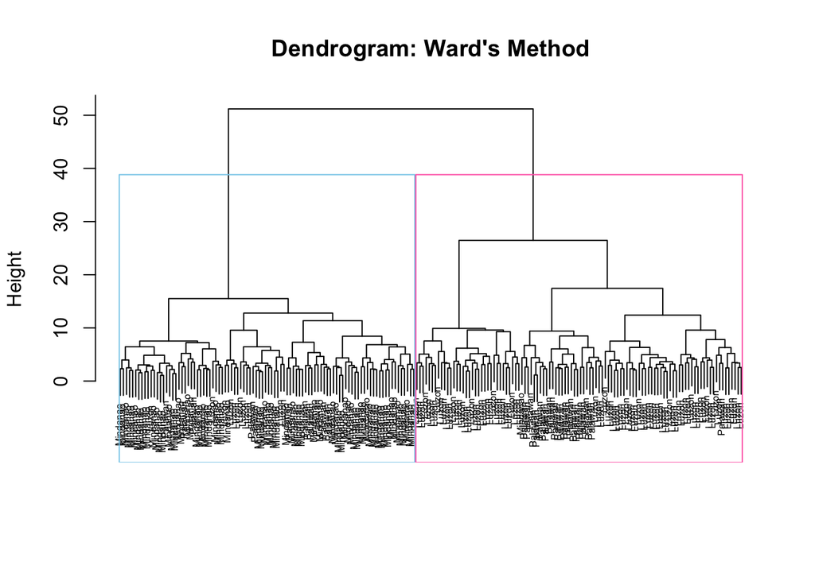

```r
# Setup
optK_wards <- 2
optK_sLink <- 2
df_final <- as.data.frame(scaled_data)
df_final$Pop <- my_data$Pop[complete.cases(numeric_data)]


# Dendogram for Ward's
plot(hc_wards,
     main = "Dendrogram: Ward's Method",
     sub = "",
     xlab = "",
     labels = df_final$Pop,
     cex = 0.5)
rect.hclust(hc_wards,
            k = optK_wards,
            border = c("skyblue","hotpink"))
```

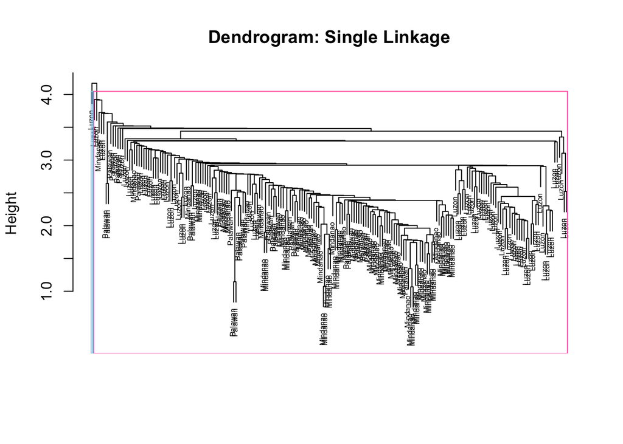

```r
# Dendogram for Single Linkage
plot(hc_sLink,
     main = "Dendrogram: Single Linkage",
     sub = "",
     xlab = "",
     labels = df_final$Pop,
     cex = 0.5)
rect.hclust(hc_sLink,
            k = optK_sLink,
            border = c("skyblue", "hotpink"))
```

## K-means vs Hierarchal

**Revisit your K-means outputs from the previous activity and compare how the clusters were determined.**

*Are the clusters consistent? If not, what do you think causes this, and how might it influence your interpretation of biological patterns in the data?*

Kmeans had an optimal K value of either 2 or 3 based on the Elbow plot. Meanwhile in Hierarchal (Agglomerative), both Ward’s and Single Linkage method had an optimal value of 2 based on the Silhouette’s Loop.

The clusters of Wards and Kmeans were pretty similar looking based on the “Pop” labels with one cluster consisting mostly of Mindanao and the other being a mix of Luzon and Palawan. This maybe because they share a similar mathematical foundation that minimizes the distance between data points within clusters. While single linkage computes the distance between closest clusters based on the nearest neighbors.

So, Single Linkage and Ward’s provide different clustering results. But they each provide a different insight, single linkage could reveal any outliers while kmeans and ward’s might compact them with other points.